```python
#%pylab inline
%matplotlib inline
from matplotlib import pylab as plt
import numpy as np
plt.xkcd()
```

# Algorytmy genetyczne w praktyce

[figure not shown]

### Grzegorz Parka

Jak wiemy, na naszym wydziale mamy rozbudowane zajęcia z matematyki stosowanej. Dobrze znamy granice ciągów, szeregi, pochodne i całki. Znamy też składnie języków programowania takich jak C, C++ i Java.

Jeśli chodzi o teorię, jesteśmy dobrze przygotowani. Sprawa staje się trudniejsza, kiedy musimy naszą wiedzę wykorzystać w praktyce.

Dlatego chciałbym po dzisiejszej prezentacji zaprosić chętnych do pracy w zespole nad zaprojektowaniem i zaimplementowaniem w dowolnej technologii wybranego algorytmu genetycznego.

## Rozkład jazdy

- Co to jest algorytm genetyczny
- Podstawowe operacje genetyczne
- Realizacja algorytmu genetycznego
- Przykłady użycia algorytmów genetycznych
- Pomysły na hackathon

## Algorytm genetyczny

- Narzędzie inspirowane procesami ewolucyjnymi zachodzącymi w naturze
- Ogólne narzędzie optymizacji

Narzędzie ogólne - tzn. że można je zastosować do bardzo dużego zbioru problemów, a szczególnie takich, dla których trudno sformułować precyzyjny model matematyczny oraz takich, w których mamy do przeszukania bardzo dużą przestrzeń rozwiązań.

Warto w tym miejscu zaznaczyć, że algorytm genetyczny nie gwarantuje nam uzyskania globalnego optimum, powinniśmy się raczej spodziewać rozwiązania przybliżonego.

- Jedna z metod sztucznej inteligencji

Inne metody sztucznej inteligencji to inspirowane biologią, sieci neuronowe i algorytmy ewolucyjne (uogólnienie algorytmów genetycznych, przykład: algorytmy roju), ponadto systemy oparte na wiedzy (systemy ekspertowe), statystyce (uczenie maszynowe) lub logice (prolog).

## Inspiracja biologiczna

[figure not shown]

Struktura chemiczna DNA

Cechy organizmów żywych są kodowane w DNA. Cząsteczki DNA są zbudowane z par komplementarnych zasad połączonych wiązaniami wodorowymi, otoczonymi szkieletem z pięciowęglowego cukru -- deoksyrybozy oraz reszty fosforanowej.

Długość jednej pary zasad to około 0.34 nm. W każdej komórce człowieka znajduje się około 6 mld zasad. Średnio około 1500 sekwencji zasad koduje jeden gen. **Gen** jest podstawową jednostką dziedziczności cech. Zawiera **zakodowaną** informację jak zbudować określone białko, jak również ile, gdzie i w jakich okolicznościach je zbudować.

DNA jest zorganizowane w **chromosomy** -- zwinięte łańcuchy (rozwinięty łańcuch z jednej komórki człowieka zająłby ok 2m). Komórki różnych organizmów posiadają różne ilości chromosomów. Np. komórki człowieka posiadają 1 parę chromosomów odpowiadających za dziedziczenie cech płciowych (XX-kobieta, XY-facet) oraz 22 pary autosomów odpowiadających za dziedziczenie innych cech.

Krzyżowanie

[figure not shown]

W przypadku gamet części chromosomów mogą podlegać **krzyżowaniu**. Krzyżowanie pomaga zróżnicować materiał genetyczny w populacji. Dziecko może posiadać inną konfigurację genów niż jego rodzice.

Mutacja

[figure not shown]

Niezależnie w każdym z genów może wystąpić przypadkowa mutacja. Zwykle nie jest istotna, jednak czasami może doprowadzić do zmiany określonych cech osobnika.

Możemy wydzielić różne rodzaje mutacji, np. usunięcie części chromosomu, zduplikowanie częsci chromosomu, odwrócenie kawałka chromosomu, albo wstawienie części chromosomu do innego chromosomu.

Selekcja

[figure not shown]

Osobniki w populacji mogą mieć różne cechy, niektóre pożądane, inne niekoniecznie. Osobniki o lepszych cechach będą częściej miały okazję do przekazania materiału genetycznego dalej. Z czasem ich kod genetyczny będzie coraz bardziej powszechny w populacji. W ten sposób populacja zbiega do optimum.

Przypadkiem mogą być chociażby żyrafy, które w procesie ewolucji wyhodowały sobie długie szyje umożliwiające im zdobywanie pożywienia niedostępnego dla innych zwierząt roślinożernych.

## Dobra, dobra! Tylko jak to zaimplementować w programie?

[figure not shown]

Przećwiczmy to na prostym przykładzie.

## Problem

Znajdź maksimum funkcji $y = sin(\pi x)^{20} + sin(3\pi x)^2$ na przedziale $x \in [0,1]$

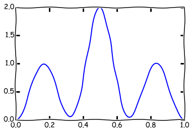

```python
x = np.linspace(0, 1, 100)
y = np.sin(np.pi*x)**20 + np.sin(3.0*np.pi*x )**2

plt.plot(x, y)
plt.show()
```

## Kodowanie

Zastosujemy proste kodowanie binarne. Genotypem będzie lista o określonej długości, wypełniona zerami i jedynkami.

```python
import random
class Individual(object):
    length = 5
    alleles = (0,1)
    def __init__(self):
        self.genotype = [random.choice(self.alleles) for i in xrange(self.length)]

    def __repr__(self):
        return '<%s: chromosome=%s>' % \
                (self.__class__.__name__,
                 self.genotype)

dude = Individual()
print dude
```

```
<Individual: chromosome=[1, 1, 0, 0, 1]>
```

## Dekodowanie

```python
length = 5
def fenotype(chromosome):
    return sum( [ 2**n *chromosome[n] for n in xrange(length)]) / float(2**length)

chromosome = [0,0,0,0,1]
print chromosome, "->" ,fenotype(chromosome)
```

```
[0, 0, 0, 0, 1] -> 0.5
```

## Krzyżowanie

Polega na wymianie części list między osobnikami. Może być jednopunktowe lub dwupunktowe. Dla prostoty, jednopunktowe.

```python
def crossover(mom, dad):
    point = random.randrange(0,length)
    mom[:point], dad[:point] = dad[:point], mom[:point]

mom = [0,0,0,0,0]
dad = [1,1,1,1,1]

crossover(mom, dad)
print "New mom: ", mom
print "New dad: ", dad
```

```
New mom:  [1, 1, 1, 1, 0]
New dad:  [0, 0, 0, 0, 1]
```

## Mutacja

Polega na losowej zmianie jednego genu.

```python
alleles = (0,1)

def mutate(chromosome, gene):
    chromosome[gene] = random.choice(alleles)

dude = [1,1,1,1,1]
mutate(dude, 0)
print dude
```

```
[0, 1, 1, 1, 1]
```

## Funkcja przystosowania

Selekcja będzie promowała osobniki o większej wartości funkcji celu. W przypadku naszego problemu funkcja celu to po prostu $f(x) = sin(\pi x)^{20} + sin(3\pi x)^2$

```python
from math import sin, pi

def evaluate(chromosome):
    x = fenotype(chromosome)
    return sin(pi*x)**20 + sin(3*pi*x)**2

chromosome = [0,0,0,0,1]
print chromosome, "->", evaluate(chromosome)
```

```
[0, 0, 0, 0, 1] -> 2.0
```

## Osobnik

```python
class Individual(object):
    alleles = (0,1)
    length = 100

    def __init__(self, chromosome=None):
        self.chromosome = chromosome or [random.choice(self.alleles) for i in xrange(self.length)]
        self.fitness = None

    def evaluate(self):
        self._calculate_fitness()

    def mutate(self):
        self._swap_gene()

    def crossover(self, other):
        return self._single_point_crossover(other)


    def _swap_gene(self):
        allel = random.randrange(0,self.length)
        self.chromosome[allel] = random.choice(self.alleles)

    def _calculate_fitness(self):
        x = self.fenotype()
        self.fitness = sin(pi*x)**20 + sin(3*pi*x)**2

    def fenotype(self):
        return sum([self.chromosome[n]*2**n for n in xrange(self.length)]) / 2.0**self.length

    def _single_point_crossover(self, other):
        pt = random.randrange(1,self.length)
        self.chromosome[:pt], other.chromosome[:pt] = other.chromosome[:pt], self.chromosome[:pt]
        return self, other

    def __repr__(self):
        return '<%s fenotype=%s, fitness=%s>' % \
               (self.__class__.__name__,
                self.fenotype(), self.fitness)

    def __cmp__(self, other):
        return cmp(other.fitness, self.fitness)

    def copy(self):
        twin = self.__class__(self.chromosome[:])
        twin.fitness = self.fitness
        return twin
```

## Populacja

### Wielkość populacji

[figure not shown]

Im większa populacja, tym większa różnorodność genetyczna, ale i dłuższy czas dochodzenia do zbieżności. W przypadku prostych problemów zwykle wystarcza populacja kilku osobników. Dla skomplikowanych problemów wielkość populacji można liczyć w setkach/tysiącach.

### Prawdopodobieństwo krzyżowania

[figure not shown]

Krzyżowanie odpowiada za mieszanie cech wśród osobników. Im większe prawdopodobieństwo krzyżowania, tym większa szansa na uzyskanie osiągnięcie pozytywnej synergii między osobnikami. Prawidłowo dobrane krzyżowanie zwykle działa dobrze przy prawdopodobieństwie krzyżowania 0.5-1.0

### Prawdopodobieństwo mutacji

[figure not shown]

Mutacja pełni rolę szumu, ma zapewnić większą różnorodność osobników w populacji. Za niskie prawdopodobieństwo mutacji sprawia, że algorytm za szybko zbiega, zwykle do nieoptymalnego rozwiązania. Za wysokie prawdopodobieństwo mutacji sprawia, że algorytm staje się losowy i nie osiąga zbieżności. Typowe prawdopodobieństwo mutacji to 0.01-0.05.

### Typ selekcji

[figure not shown]

Określa na jakiej podstawie dobieramy osobniki, które mają przejść do następnego pokolenia. Najpopularniejsze metody selekcji to metoda ruletki lub turniejowa. Kryteria selekcji można zmieniać i skalować w trakcie ewolucji. W zależności od problemu, różne sposoby selekcji mogą wykazywać różną wydajność.

```python
class Population(object):
    def __init__(self, pop_size = 10, mutation_prob = 0.01, crossover_prob = 0.8):
        self.pop_size = pop_size
        self.mutation_prob = mutation_prob
        self.crossover_prob = crossover_prob

        self.population = [Individual() for i in xrange(pop_size)]
        for one in self.population:
            one.evaluate()

    def evolve(self):
        self.population.sort()
        self._crossover()
        self._mutate()

    def _mutate(self):
        for chromosome in self.population:
            for gene in chromosome.chromosome:
                if random.random() < self.mutation_prob:
                    chromosome.mutate()

    def _crossover(self):
        next_population = [self.best.copy()]
        while len(next_population) < self.pop_size:
            mate1 = self._select()
            if random.random() < self.crossover_prob:
                mate2 = self._select()
                offspring = mate1.crossover(mate2)
            else:
                offspring = [mate1.copy()]
            for individual in offspring:
                individual.evaluate()
                next_population.append(individual)
        self.population = next_population[:self.pop_size]

    def _select(self):
        """preferred selection method"""
        return self._tournament()

    def _tournament(self, size=5, choosebest=0.80):
        competitors = [random.choice(self.population) for i in range(size)]
        competitors.sort()
        if random.random() < choosebest:
            return competitors[0]
        else:
            return random.choice(competitors[1:])

    @property
    def best(self):
        """individual with best fitness score in population."""
        for one in self.population:
            one.evaluate()
        self.population.sort()
        return self.population[0]

    @property
    def average(self):
        return sum([one.fitness for one in self.population])/float(self.pop_size)
```

```
Best fitness: 1.99838116693
```

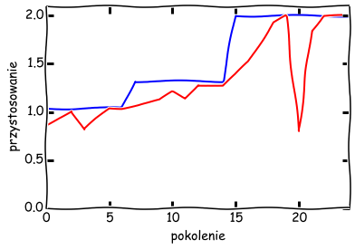

```python
random.seed(None)

population = Population(pop_size=10, mutation_prob=0.01, crossover_prob=0.8)
bests = []
averages = []
generations = 25

for i in xrange(generations):
    population.evolve()
    bests.append(population.best.fitness)
    averages.append(population.average)

plt.xlabel("pokolenie")
plt.ylabel("przystosowanie")
plt.axis((0,generations-1, 0, 2.1))
plt.plot(bests)
plt.plot(averages)
print "Best fitness:",bests[-1]
```

Pokazać efekt zmiany **prawdopodobieństwa mutacji** (przy $p_m$ = 1.0 losowość), krzyżowania (duże $p_c$ - większe skoki średniego przystosowania) i wielkości populacji (różna ilość pokoleń do uzyskania zbieżności)

Oczywiście osobniki nie muszą być kodowane binarnie. Parametry osobników mogą być przechowywane jako liczby całkowite lub rzeczywiste. Wymaga to innego skonstruowania operatorów krzyżowania i mutacji.

# Problem komiwojażera (TSP)

[figure not shown]

Mając dany zbiór miast i możliwych połączeń między parami miast, zadaniem jest znalezienie najkrótszej drogi, która pozwoli odwiedzić każde z miast i wrócić do punktu wyjścia.

Znajdź najkrótszą drogę między wierzchołkami grafu.

[figure not shown]

```python
from IPython.display import HTML
HTML('<iframe src=http://gmaps-samples-v3.googlecode.com/svn/trunk/drivingdirections/directions-optimized.html width=670 height=550></iframe>')
```

[interactive chart not shown]

Problem permutacyjny

Problem NP-trudny, znalezienie optymalnego rozwiązania w czasie dłuższym niż wielomianowy.

Brute-force w czasie O(n!) -- rozwiązywalne tylko dla małych n

Istnieją szybsze algorytmy przybliżone.

### Cechy algorytmu genetycznego rozwiązującego TSP

Krzyżowanie nie dublujące krawędzi (PMX, OX, ERX, ...)

Implementacja dołączona do prezentacji

```python
import random
from math import sqrt

class Chromosome(object):

    def __init__(self, chromosome=None, shuff = 0):
        self.chromosome = chromosome
        if shuff == 1:
            random.shuffle(chromosome)
        self.fitness = None

    def evaluate(self):
        self._calculate_fitness()

    def mutate(self):
        self._swap_genes()

    def crossover(self, other):
        return self._PMX_crossover(other)


    def _swap_genes(self):
        allel_one = random.randrange(0,len(self.chromosome))
        allel_two = random.randrange(0,len(self.chromosome))
        self.chromosome[allel_one], self.chromosome[allel_two] = self.chromosome[allel_two], self.chromosome[allel_one]

    def _calculate_fitness(self):
        self.fitness = 0
        for i in xrange(0, len(self.chromosome)):
            self.fitness += sqrt((self.chromosome[i][1] - self.chromosome[i-1][1])**2 + ((self.chromosome[i][2] - self.chromosome[i-1][2])**2))

    def fenotype(self):
        return [vert[0] for vert in self.chromosome]

    def _PMX_crossover(self, other):
        size = min(len(self.chromosome), len(other.chromosome))
        p1, p2 = [0]*size, [0]*size

        # Initialize the position of each indices in the individuals
        for i in xrange(size):
            p1[self.chromosome[i][0]] = i
            p2[other.chromosome[i][0]] = i
        # Choose crossover points
        cxpoint1 = random.randint(0, size)
        cxpoint2 = random.randint(0, size - 1)
        if cxpoint2 >= cxpoint1:
            cxpoint2 += 1
        else: # Swap the two cx points
            cxpoint1, cxpoint2 = cxpoint2, cxpoint1

        # Apply crossover between cx points
        for i in xrange(cxpoint1, cxpoint2):
            # Keep track of the selected values
            temp1 = self.chromosome[i]
            temp2 = other.chromosome[i]

            # Swap the matched value
            self.chromosome[i], self.chromosome[p1[temp2[0]]] = temp2, temp1
            other.chromosome[i], other.chromosome[p2[temp1[0]]] = temp1, temp2
            # Position bookkeeping
            p1[temp1[0]], p1[temp2[0]] = p1[temp2[0]], p1[temp1[0]]
            p2[temp1[0]], p2[temp2[0]] = p2[temp2[0]], p2[temp1[0]]

        return self, other

    def __repr__(self):
        return '<%s fenotype=%s ... , fitness=%s>' % \
               (self.__class__.__name__,
                 self.fenotype()[:5], self.fitness)

    def __cmp__(self, other):
        return cmp(self.fitness, other.fitness)

    def copy(self):
        twin = self.__class__(self.chromosome[:])
        twin.fitness = self.fitness
        return twin
```

```python
class Population(object):

    def __init__(self, data_src = None, pop_size = 40, mutation_prob = 0.00, crossover_prob = 1.0):
        self.pop_size = pop_size
        self.mutation_prob = mutation_prob
        self.crossover_prob = crossover_prob

        self.population = [Chromosome(chromosome = data_src, shuff = True) for i in xrange(pop_size)]
        for one in self.population:
            one.evaluate()

    def evolve(self):
        self.population.sort()
        self._crossover()
        self._mutate()

    def _mutate(self):
        for chromosome in self.population:
            for gene in chromosome.chromosome:
                if random.random() < self.mutation_prob:
                    chromosome.mutate()

    def _crossover(self):
        next_population = [self.best.copy()]
        while len(next_population) < self.pop_size:
            mate1 = self._select()
            if random.random() < self.crossover_prob:
                #print "crossing over!!"
                mate2 = self._select()
                offspring = mate1.crossover(mate2)
            else:
                offspring = [mate1.copy()]
            for individual in offspring:
                individual.evaluate()
                next_population.append(individual)
        self.population = next_population[:self.pop_size]

    def _select(self):
        """preferred selection method"""
        return self._tournament()

    def _tournament(self, size=8, choosebest=0.80):
        competitors = [random.choice(self.population) for i in range(size)]
        competitors.sort()
        if random.random() < choosebest:
            return competitors[0]
        else:
            return random.choice(competitors[1:])

    @property
    def best(self):
        """individual with best fitness score in population."""
        for one in self.population:
            one.evaluate()
            self.population.sort()
        return self.population[0]

    @property
    def average(self):
        return sum([one.fitness for one in self.population])/float(self.pop_size)
```

```python
f = open("data/tsp_data_29.dat")
lines = f.readlines()
f.close()

vertices = []
for line in lines:
    line = line.split(' ')
    vertices.append( [int(line[0])-1, float(line[1]), float(line[2])] )
```

```python
random.seed(None)
bests = []
averages = []
```

```
Best fitness: 32512.9834507
<Chromosome fenotype=[13, 12, 16, 17, 18] ... , fitness=32512.9834507>
```

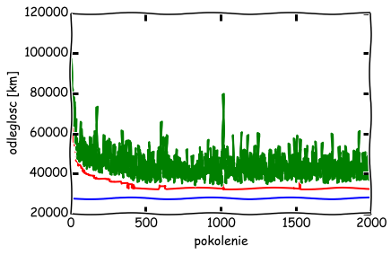

```python
population = Population(data_src = vertices, pop_size=20, mutation_prob=0.02, crossover_prob=0.35)
generations = 2000

for i in xrange(generations):
    population.evolve()
    bests.append(population.best.fitness)
    averages.append(population.average)

plt.xlabel("pokolenie")
plt.ylabel("odleglosc [km]")
plt.plot(bests, color="red")
plt.plot(averages, color = "green")
optimum = [27603]*generations #znane optimum
plt.plot(optimum, color = "blue")
print "Best fitness:",bests[-1]
print population.best
```

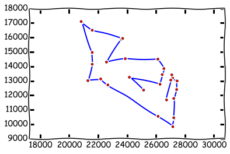

```python
fig, ax = plt.subplots()
x, y = [vert[1] for vert in population.best.chromosome], [vert[2] for vert in population.best.chromosome]
line, = ax.plot(x, y, ls='-', marker='o', markersize=4, markerfacecolor="red")

ax.axis('equal')
plt.show()
```

Podobny test dla zestawu 131 miast wypadł znacznie gorzej. Żeby rozwiązywać większe problemy, należałoby przemyśleć sposób kodowania i wykonywania operatorów genetycznych - zastosować inny typ krzyżowania lub losowo dobieraną kombinację typów krzyżowania. Można też dodać operację inwersji jako jeden z typów mutacji.

Przykładowe zbiory danych testowych z rozwiązaniami: http://www.math.uwaterloo.ca/tsp/data/

### Zastosowania algorytmu TSP

- Wyznaczanie optymalnej trasy - logistyka
- Wyznaczanie optymalnego przebiegu ścieżek w obwodach drukowanych (problemy wielkości $n \approx 10^6 - 10^8$)
- Podproblemy przy sekwencjonowaniu genomu ($n \approx 10^{10}$)

### Podobne problemy

- inne problemy permutacyjne

# Programowanie genetyczne

J.R.Koza: http://www.genetic-programming.com

Program i funkcja mogą zostać przedstawione w postaci drzewa argumentów i kolejnych operacji.

[figure not shown]

### Problem

Zaprojektuj 3-bitowy konwerter liczb binarnych na kod graya.

[figure not shown]

Wiele układów, w szczególności elektrycznych oraz cyfrowych, możemy przedstawić w ogólności w formie czarnej skrzynki, która przyjmuje coś na wejściu i coś zwraca. Kiedy mamy już troszkę wiedzy na temat np. elektroniki, zauważamy, że w przypadku układu elektrycznego analogowego, będą tam pewnie jakieś oporniki, cewki, kondensatory, wzmacniacze operacyjne itp.

W przypadku układów cyfrowych będą to pewnie bramki logiczne (AND, OR, NOR, XOR ...) o różnej liczbie wejść.

| DEC | BIN | GRAY |
| --- | --- | --- |
| 0 | 000 | 000 |
| 1 | 001 | 001 |
| 2 | 010 | 011 |
| 3 | 011 | 010 |
| 4 | 100 | 110 |
| 5 | 101 | 111 |
| 6 | 110 | 101 |
| 7 | 111 | 100 |

W tym konkretnym przypadku chcemy dla każdej podanej liczby binarnej 3-bitowej otrzymać na wyjściu jej reprezentację w kodzie Graya, według powyższej tabelki.

W podobny sposób możemy projektować różne urządzenia mechaniczne i elektryczne, których konstrukcje potrafimy składać z mniejszych klocków oraz oceniać poszczególne rozwiązania. Możemy w ten sposób projektować także funkcje czy wręcz całe programy.

# Przykłady zastosowań algorytmów genetycznych

### Genetyczny optymizer zapytań SQL w PostgreSQL

[figure not shown]

- SELECT * FROM A JOIN B JOIN C JOIN D
  - kolejność JOINów ma znaczenie
- Drzewo joinów

[figure not shown]

- Problem permutacyjny -- podejście podobne jak do problemu komiwojażera

Instytut Automatyki z University of Mining and Technology we Freibergu w Niemczech napotkał problemy przy wykorzystaniu bazy danych PostgreSQL w systemie zarzadzania siecią elektryczną. W zapytaniach SQL znajdowało się wiele operatorów JOIN łaczących dane z tabeli znajdujących się w różnych węzłach systemu rozproszonego.

Wydajność zapytań z użyciem JOINów może byc różna w zależnosci od tego w jakiej kolejności tabele będą ze sobą łączone. Ilość możliwych realizacji zapytań zawierających operatory JOIN rosnie wykładniczo ze wzrostem ilości JOINów. W zwiazku z tym nie można było uzyc standardowego optymizera zapytań. Przeszukiwał on niemal całą przestrzeń możliwych strategii i dla wysokowymiarowych problemów działał zbyt wolno oraz zużywał za dużo pamięci. Do znajdowania własciwych strategii zapytań zdecydowano sie użyć algorytmu genetycznego.

Genetyczny optymizer zapytań (GEQO) podchodzi do zadania optymalizacji jak do problemu komiwojażera. Możliwe plany zapytań są zakodowane jako łańcuchy znaków. Każdy z nich reprezentuje kolejność wykonywanych operacji JOIN.

```python
HTML('<iframe src=http://doxygen.postgresql.org/dir_7175d082973170882d93e297d0d6db83.html width=900 height=550></iframe>')
```

[interactive chart not shown]

Determinizm dzięki zastosowaniu stałego ziarna i stałych prawdopodobieństw krzyżowania i mutacji.

Bonus:

- developerzy PostgreSQL narzekają na kiepską jakość kodu GEQO i od dłuższego czasu zabierają się do napisania go od nowa. Biorą też pod uwagę możliwość zastosowania innego algorytmu, np. symulowanego wyżarzania.

### Rozwiązywanie praktycznych zagadnień elektromagnetyzmu

- Algorytmy genetyczne w systemach równoległych
- Problemy odwrotne elektromagnetyzmu są wymagające obliczeniowo
- ECJEXT -- równoległy system optymalizacji metodami ewolucyjnymi

Jedną z niewątpliwych zalet algorytmów genetycznych jest dobra możliwość zrównoleglenia. Przykładowym podejściem do zrównoleglania AG jest uruchomienie kilku instancji AG i okresowa migracja części osobników między pokoleniami.

Jacek Starzyński, Robert Szmurło, Bartosz Sawicki - pracownicy Wydziału Elektrycznego PW stworzyli system ECJEXT — równoległy system optymalizacji metodami ewolucyjnymi, stworzony z myślą o rozwiązywaniu problemów odwrotnych elektromagnetyzmu.

Przykładowy problem - stymulacja nerwu błędnego

[figure not shown]

Celem przykładu jest optymalne zaprojektowanie magnetycznego stymulatora nerwu błędnego. Nerw błędny jest częścią autonomicznego układu nerwowego. Nerw może być stymulowany elektrodami umieszczonymi chirurgicznie w okolicach szyi, co pozwala zapobiegać napadom padaczkowym i pomaga w walce z depresją.

Stymulacja magnetyczna pozwala uniknąć nacinania skóry i jest znacznie bardziej bezbolesną metodą niż stymulacja elektryczna.

Równanie różniczkowe, rozwiązywane na modelu numerycznym ciała człowieka, zdyskretyzowanym w postaci siatki czworościennej o 632808 krawędziach i 114405 węzłach.

Parametry cewki

[figure not shown]

Parametry cewki: promień zewnętrzny, wewnętrzny, odległość od powierzchni skóry, kąt obrotu.

Cewka o optymalnych parametrach i rozłożenie pola elektrycznego indukowanego na powierzchni skóry.

[figure not shown]

Ustawienia systemu równoległego

[figure not shown]

Przyspieszenie - praktycznie proporcjonalne do ilości użytych maszyn

[figure not shown]

Eksperymenty były przeprowadzone w uczelnianym laboratorium wyposażonym w 30 komputerów (Core2Duo 2.4GHz + 2 GB RAM, system operacyjny Red Hat Linux). Dla 30 komputerów całkowity czas rozwiązywania problemu wynosił 229 minut, dla dwóch maszyn - więcej niż 55 godzin.

### Algorytmy genetyczne przy projektowaniu żywych organizmów

Ostatnio w wiadomościach na tvn mówiono o projektowaniu dzieci. Proces miał polegać na sprawdzeniu genomu rodziców, generowaniu na ich podstawie kilkunastu tysięcy cyfrowych płodów, na których możliwe było sprawdzenie cech dzieci przed poczęciem.

# Projektowanie algorytmów genetycznych

1. Problem
2. Ocena rozwiązania
3. Sposób kodowania
4. Dobranie sposobu selekcji, krzyżowania, mutacji
5. Dobranie prawdopodobieństw krzyżowania i mutacji - raczej eksperymentalnie
6. Profit

# Hackathon!

[figure not shown]

W marcu uczestniczyłem w fajnym wydarzeniu - Arday, gdzie słuchaliśmy krótkich wykładów dotyczących platformy Arduino, a następnie mieliśmy możliwość, w małych zespołach, przerabiać omawiany materiał w praktyce. Chciałbym, wzorem tamtego spotkania, zrobić coś podobnego u nas.

Widzę to tak: paru z nas proponuje problemy, które następnie rozwiązujemy w kilkuosobowych zespołach, z użyciem algorytmów genetycznych. Na koniec prezentujemy efekty swojej pracy i cieszymy się, że zrobiliśmy coś fajnego.

W razie gdyby brakowało pomysłów, mogę zaproponować kilka swoich.

# ??

Łatwe:

- Modyfikacja przykładowego programu - znajdowanie ekstremum funkcji zależnej od 2 zmiennych.
- Dopasowanie funkcji $f^N, f \in [\exp, \sin, \cos, +, -, *, /, x_1 ... x_N]$ do zbioru danych
- Znajdowanie tożsamości trygonometrycznych
- Automatyczne testowanie wydajnościowe wybranego algorytmu sortowania

Średnie

- Znajdowanie przybliżonych całek nieoznaczonych dla funkcji niecałkowalnych analitycznie np. $\exp(-x^2), \sin(x^2), \frac{sin(x)}{x},\frac{1}{ln(x)}, x^x$
- Projektowanie obwodu elektrycznego o określonej charakterystyce (https://github.com/ahkab/ahkab/wiki/Example:-Python-API)

Trudne

- Automatyczna gra w Tetrisa, Mario
- Symulacja wybranego zjawiska fizycznego

```python
from IPython.core.display import HTML

def css_styling():
    styles = open("custom.css", "r").read()
    return HTML(styles)
css_styling()
```